# utm_latlong

Paul Apivat Hanvongse

6/25/2020

## Packages and Libraries

```r
library(maps)
library(tidyverse)
library(sp)
library(rmarkdown)
```

```r
library(knitr)
opts_chunk$set(tidy.opts=list(width.cutoff=60),tidy=TRUE)
```

## World and Thai Maps

First, we’ll use `map_data` function from `ggplot2` to turn any map from the `maps` package into a data frame. This provides longitude and lattitude data. Then, we’ll filter for Thailand to get Thai longtitude and lattitude data.

```r
world.map <- map_data("world")
head(world.map)
```

```
##        long      lat group order region subregion
## 1 -69.89912 12.45200     1     1  Aruba      <NA>
## 2 -69.89571 12.42300     1     2  Aruba      <NA>
## 3 -69.94219 12.43853     1     3  Aruba      <NA>
## 4 -70.00415 12.50049     1     4  Aruba      <NA>
## 5 -70.06612 12.54697     1     5  Aruba      <NA>
## 6 -70.05088 12.59707     1     6  Aruba      <NA>
```

```r
THAI.map <- world.map %>% filter(region == "Thailand")
head(THAI.map)
```

```
##       long      lat group order   region   subregion
## 1 99.66309 6.521924  1404 87912 Thailand Ko Tarutao
## 2 99.64404 6.516113  1404 87913 Thailand Ko Tarutao
## 3 99.60664 6.596827  1404 87914 Thailand Ko Tarutao
## 4 99.65401 6.714111  1404 87915 Thailand Ko Tarutao
## 5 99.70136 6.570557  1404 87916 Thailand Ko Tarutao
## 6 99.66309 6.521924  1404 87917 Thailand Ko Tarutao
```

## Longitude and Lattitude Value Ranges

Before converting UTM to longitude/lattitude data, we should know the range of both Longitudes and Lattitudes for Thailand.

```r
summary(THAI.map$long)
```

```
##    Min. 1st Qu.  Median    Mean 3rd Qu.    Max.
##   97.37   99.08  100.26  100.71  102.27  105.64
```

```r
summary(THAI.map$lat)
```

```
##    Min. 1st Qu.  Median    Mean 3rd Qu.    Max.
##   5.637   9.084  13.213  13.249  17.820  20.424
```

## Jobpost Data Frame

Our objective is to visualize utm_x and utm_y in the `jobpost` data frame by turning them into lattitude and longitude data first. The `jobpost` data frame is retrieved from PostgreSQL.

Preparation includes writing it to CSV before loading into Rmarkdown.

```r
jobpost <- read.csv("jobpost.csv")
glimpse(jobpost)
```

```
## Rows: 50
## Columns: 25
## $ X                 <int> 1, 2, 3, 4, 5, 6, 7, 8, 9, 10, 11, 12, 13, 14, 15, …
## $ jobpost_id        <int> 54, 66, 33, 34, 35, 36, 28, 32, 30, 55, 67, 68, 37,…
## $ job_name          <fct> "Facebook Marketing", "แอดมิน", "Accountant", "แคชเ…
## $ job_qty           <int> 3, 1, 1, 2, 2, 5, 3, 1, 5, 1, 22, 10, 1, 1, 2, 2, 1…
## $ age_min           <int> 22, 25, 29, 20, 20, 19, 28, 28, 20, 25, 30, 21, 18,…
## $ age_max           <int> 26, 32, 35, 35, 35, 40, 120, 40, 40, 45, 45, 30, 50…
## $ study_field       <fct> "-", "แฟชั่น", "-", "-", "-", "-", "-", "จัดการผักผ…
## $ job_qualification <fct> "อ่าน เขียน ภาษาอังกฤษ ได้ดี", "ตอบคำถาม ภาษาอังกฤษ…
## $ min_salary        <int> 30000, 12000, 20000, 13000, 10000, 15000, 15000, 12…
## $ job_description   <fct> "ทำการตลาดทางช่องทาง facebook", "แอดมินดูแล เพจ เสื…
## $ manychat_id       <dbl> 3.961592e+15, 2.984969e+15, 2.941175e+15, 3.416291e…
## $ job_sex           <int> 3, 3, 2, 2, 3, 3, 3, 3, 3, 3, 3, 3, 3, 2, 2, 1, 3, …
## $ study_level       <int> 5, 5, 5, 0, 2, 2, 3, 4, 4, 5, 5, 4, 0, 2, 2, 5, 5, …
## $ work_exp          <int> 1, 0, 3, 1, 0, 0, 0, 3, 0, 3, 3, 0, 0, 1, 1, 3, 6, …
## $ created           <fct> 2020-06-07 09:00:36, 2020-06-14 23:12:35, 2020-05-2…
## $ updated           <fct> 2020-06-08 09:05:23, 2020-06-14 23:12:35, 2020-05-2…
## $ confirmed         <fct> 2020-06-07 09:00:36, 2020-06-14 23:12:35, 2020-05-2…
## $ batch             <lgl> FALSE, FALSE, FALSE, FALSE, FALSE, FALSE, FALSE, FA…
## $ location          <fct> บางนา, รามอินทรา 65, พระรามเก้า ซอย 60, ห้าง ริเวอร…
## $ utm_x             <dbl> 674486.5, 678167.2, 676504.5, 661251.7, 714943.7, 6…
## $ utm_y             <dbl> 1511131, 1532008, 1519745, 1515611, 1477934, 152128…
## $ utm_zone_number   <int> 47, 47, 47, 47, 47, 47, 48, 47, 47, 47, 35, 48, 47,…
## $ utm_zone_letter   <fct> P, P, P, P, P, P, Q, P, P, P, L, P, P, P, P, P, P, …
## $ job_type          <int> NA, NA, 0, 0, 0, 0, 0, 0, 0, NA, NA, NA, 0, 0, 0, 0…
## $ online            <lgl> NA, NA, FALSE, FALSE, FALSE, FALSE, FALSE, FALSE, F…
```

## Subset Data Frame called UTM

We’ll select only `utm_x` and `utm_y` columns from `jobpost` because we’re interested in these two columns.

```r
utm <- data.frame(jobpost$utm_x, jobpost$utm_y)
str(utm)
```

```
## 'data.frame':    50 obs. of  2 variables:
##  $ jobpost.utm_x: num  674486 678167 676504 661252 714944 ...
##  $ jobpost.utm_y: num  1511131 1532008 1519745 1515611 1477934 ...
```

## Handle Missing Values and Outliers

Row 50 in `jobpost` and also `utm` is missing so we’ll delete that. Then we’ll also delete row 11 because it’s location is Zambia, Africa and its longitude and lattitude numbers are very different from Thailand - which will *distort* the map.

```r
utm <- utm[-50, ]
utm <- utm[-11, ]
jobpost <- jobpost[-50, ]
jobpost <- jobpost[-11, ]
str(utm)
```

```
## 'data.frame':    48 obs. of  2 variables:
##  $ jobpost.utm_x: num  674486 678167 676504 661252 714944 ...
##  $ jobpost.utm_y: num  1511131 1532008 1519745 1515611 1477934 ...
```

```r
str(jobpost)
```

```
## 'data.frame':    48 obs. of  25 variables:
##  $ X                : int  1 2 3 4 5 6 7 8 9 10 ...
##  $ jobpost_id       : int  54 66 33 34 35 36 28 32 30 55 ...
##  $ job_name         : Factor w/ 48 levels ".Net Developer",..: 6 48 2 21 19 39 11 35 4 42 ...
##  $ job_qty          : int  3 1 1 2 2 5 3 1 5 1 ...
##  $ age_min          : int  22 25 29 20 20 19 28 28 20 25 ...
##  $ age_max          : int  26 32 35 35 35 40 120 40 40 45 ...
##  $ study_field      : Factor w/ 19 levels "-","Food science",..: 1 12 1 1 1 1 1 6 1 5 ...
##  $ job_qualification: Factor w/ 41 levels "-","- มีใบขับขี่รถยนต์\n- ผ่านการเกณฑ์ทหาร",..: 41 16 9 38 37 32 33 30 15 23 ...
##  $ min_salary       : int  30000 12000 20000 13000 10000 15000 15000 12000 11500 25000 ...
##  $ job_description  : Factor w/ 50 levels "- Develops, modifies application software according to specifications and requirements.\n- Develops application"| __truncated__,..: 30 50 27 4 16 14 15 23 7 47 ...
##  $ manychat_id      : num  3.96e+15 2.98e+15 2.94e+15 3.42e+15 3.00e+15 ...
##  $ job_sex          : int  3 3 2 2 3 3 3 3 3 3 ...
##  $ study_level      : int  5 5 5 0 2 2 3 4 4 5 ...
##  $ work_exp         : int  1 0 3 1 0 0 0 3 0 3 ...
##  $ created          : Factor w/ 26 levels "2020-05-29 14:21:22",..: 12 24 1 1 1 1 1 1 1 13 ...
##  $ updated          : Factor w/ 33 levels "2020-05-29 14:21:22",..: 19 30 1 7 1 8 1 1 6 22 ...
##  $ confirmed        : Factor w/ 26 levels "2020-05-29 14:21:22",..: 12 24 1 1 1 1 1 1 1 13 ...
##  $ batch            : logi  FALSE FALSE FALSE FALSE FALSE FALSE ...
##  $ location         : Factor w/ 50 levels "112/3 หมู่ 7 ต.บางโฉลง อ.บางพลี จ.สมุทรปราการ 10540",..: 25 35 29 47 30 9 38 11 49 39 ...
##  $ utm_x            : num  674486 678167 676504 661252 714944 ...
##  $ utm_y            : num  1511131 1532008 1519745 1515611 1477934 ...
##  $ utm_zone_number  : int  47 47 47 47 47 47 48 47 47 47 ...
##  $ utm_zone_letter  : Factor w/ 4 levels "L","N","P","Q": 3 3 3 3 3 3 4 3 3 3 ...
##  $ job_type         : int  NA NA 0 0 0 0 0 0 0 NA ...
##  $ online           : logi  NA NA FALSE FALSE FALSE FALSE ...
```

## Conversion of UTM into Lat/Long

We’ll create two SpatialPoints object classes. Then transform them into a data frame containing lat and long data.

Remember to load `sp` library for this operation.

```r
sputm <- SpatialPoints(utm, proj4string = CRS("+proj=utm +zone=47N +datum=WGS84"))
spgeo <- spTransform(sputm, CRS("+proj=longlat +datum=WGS84"))

thai.map2 <- data.frame(Location = jobpost$location, lat = spgeo$jobpost.utm_y,
    long = spgeo$jobpost.utm_x)

head(thai.map2)
```

```
##                                      Location      lat     long
## 1                                       บางนา 13.66385 100.6132
## 2                                 รามอินทรา 65 13.85233 100.6486
## 3                            พระรามเก้า ซอย 60 13.74159 100.6324
## 4 ห้าง ริเวอร์ไซด์ พลาซ่า เจริญนคร ชั้น 1 ใน้ บันไดเลื่อน 13.70512 100.4912
## 5                                    เมืองชลบุรี 13.36114 100.9847
## 6                                      กรุงเทพ 13.75633 100.5018
```

## Visualize with GGPLOT2

Here we’ll visualize the `THAI.map` we created previously and overlay the new Lat/Long data points (from UTM).

We can see a concentration of `utm` data points from `jobpost` were made in Bangkok and the greater Bangkok areas with some jobs also posted outside Bangkok.

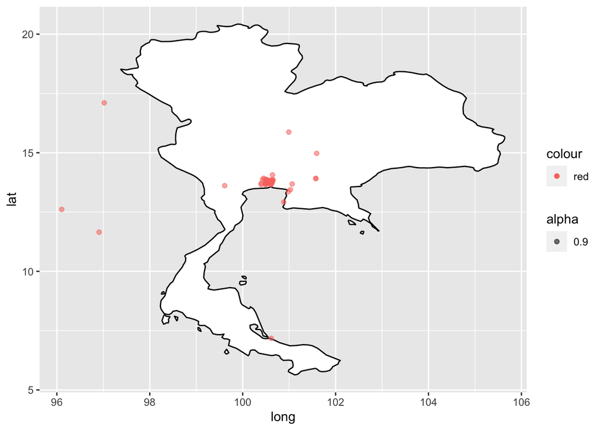

```r
THAI.map %>% ggplot() + geom_map(map = THAI.map, aes(x = long,
    y = lat, map_id = region), fill = "white", color = "black") +
    geom_point(data = thai.map2, aes(x = long, y = lat, color = "red",
        alpha = 0.9))
```